# LDA Creation for Supervised Learning

Emmitt Tucker

June 1, 2018

# Introduction

In the NanoBiology Lab at the University of Massachusetts Boston a project is being conducted to create a machine that can autonomously monitor water quality. This project was created to access the ability to preform linear discrimination analysis on the RGB values of water test strips at different discreet values. These linear discriminants would be used to train a supervised learning model that understands the nature of the RGB data. For this report a single function was created, “LDA_MODEL”, which created a LDA model and then compared this model with original data and test data. This function also accessed the accuracy of the prediction at each discreet value.

# Code

```r
library(readxl)
library(MASS)
library(caret)
library(ISLR)
library(stringr)
```

```r
LDA_MODEL <- function(TYPE){
  LDA_data <- read_excel("freshwater.xlsx",sheet=TYPE)

  if(TYPE=="nitrate"){

    na_test <- read_excel("freshwater.xlsx",sheet="nitrate_test")

    na_lda <- lda(value~.,
                  # Value is the independent variable of this LDA

                  LDA_data,
                  # The datasheet object created outside of this loop is used as the data for this LDA

                  prior=c(1,1,1,1,1,1)/6)
                  # This is equal to the prior proportions of the values
                  # There are 6 discreet for Nitrate, hence the numbering

    # This block of code creates an LDA of the Nitrate data

    plot(na_lda)
    # Creates a plot of the lda created

    na_table <- table(predict(na_lda,type="class")$class,LDA_data$value)
    # Creates a table showing the LDA predicting the values on the original datasheet

    print("Confusion Matrix With Original Data")
    print(na_table)
    # Prints out the previously created table

    print("Total Prediction Accuracy")
    print(sum(diag(na_table))/sum(na_table)*100)
    # Computes the accuracy of the LDA relative to the data within the original datasheet

    print("0 Prediction Accuracy")
    print((na_table[1,1]/sum(na_table[1,])*100))

    print("20 Prediction Accuracy")
    print((na_table[2,2]/sum(na_table[2,])*100))

    print("40 Prediction Accuracy")
    print((na_table[3,3]/sum(na_table[3,])*100))

    print("80 Prediction Accuracy")
    print((na_table[4,4]/sum(na_table[4,])*100))

    print("160 Prediction Accuracy")
    print((na_table[5,5]/sum(na_table[5,])*100))

    print("200 Prediction Accuracy")
    print((na_table[6,6]/sum(na_table[6,])*100))


    na_pred <- predict(na_lda,na_test)

    # Creates a prediction of values of the test datasheet

    na_pred_table <- table(na_pred$class, na_test$value)
    # Creates a table that shows the confusion Matrix Generated

    print("Confusion Matrix with Test Data")
    print(na_pred_table)

    print("Total Prediction Accuracy")
    print((sum(diag(na_pred_table))/sum(na_pred_table)*100))
    # Prints the accuracy of the LDA predictor

    print("0 Prediction Accuracy")
    print((na_pred_table[1,1]/sum(na_pred_table[1,])*100))

    print("20 Prediction Accuracy")
    print((na_pred_table[2,2]/sum(na_pred_table[2,])*100))

    print("40 Prediction Accuracy")
    print((na_pred_table[3,3]/sum(na_pred_table[3,])*100))

    print("80 Prediction Accuracy")
    print((na_pred_table[4,4]/sum(na_pred_table[4,])*100))

    print("160 Prediction Accuracy")
    print((na_pred_table[5,5]/sum(na_pred_table[5,])*100))

    print("200 Prediction Accuracy")
    print((na_pred_table[6,6]/sum(na_pred_table[6,])*100))

    # Each of the lines of code shows the accuracy of the LDA predictor at different discreet values
  }

  if(TYPE=="nitrite"){

    ni_test <- read_excel("freshwater.xlsx",sheet="nitrite_test")

    ni_lda <- lda(value~.,
                  LDA_data,
                  prior=c(1,1,1,1,1,1)/6)

    plot(ni_lda)

    ni_table <- table(predict(ni_lda,type="class")$class,LDA_data$value)

    print("Confusion Matrix with Original Data")
    print(ni_table)

    print("Total Prediction Accuracy")
    print((sum(diag(ni_table))/sum(ni_table)*100))

    print("0 Prediction Accuracy")
    print((ni_table[1,1]/sum(ni_table[1,])*100))

    print("0.5 Prediction Accuracy")
    print((ni_table[2,2]/sum(ni_table[2,])*100))

    print("1 Prediction Accuracy")
    print((ni_table[3,3]/sum(ni_table[3,])*100))

    print("3 Prediction Accuracy")
    print((ni_table[4,4]/sum(ni_table[4,])*100))

    print("5 Prediction Accuracy")
    print((ni_table[5,5]/sum(ni_table[5,])*100))

    print("10 Prediction Accuracy")
    print((ni_table[6,6]/sum(ni_table[6,])*100))

    ni_pred <- predict(ni_lda,ni_test)

    ni_pred_table <- table(ni_pred$class, ni_test$value)

    print("Confusion Matrix with Test Dataset")
    print(ni_pred_table)

    print("Total Prediction Accuracy")
    print((sum(diag(ni_pred_table))/sum(ni_pred_table)*100))

    print("0 Prediction Accuracy")
    print((ni_pred_table[1,1]/sum(ni_pred_table[1,])*100))

    print("0.5 Prediction Accuracy")
    print((ni_pred_table[2,2]/sum(ni_pred_table[2,])*100))

    print("1 Prediction Accuracy")
    print((ni_pred_table[3,3]/sum(ni_pred_table[3,])*100))

    print("3 Prediction Accuracy")
    print((ni_pred_table[4,4]/sum(ni_pred_table[4,])*100))

    print("5 Prediction Accuracy")
    print((ni_pred_table[5,5]/sum(ni_pred_table[5,])*100))

    print("10 Prediction Accuracy")
    print((ni_pred_table[6,6]/sum(ni_pred_table[6,])*100))
  }

  if(TYPE=="hardness"){

    ha_test <- read_excel("freshwater.xlsx",sheet="hardness_test")

    ha_lda <- lda(value~.,
                  LDA_data,
                  prior=c(1,1,1,1,1)/5)

    plot(ha_lda)

    ha_table <- table(predict(ha_lda,type="class")$class,LDA_data$value)

    print("Confusion Matrix With Original Data")
    print(ha_table)

    print("Total Prediction Accuracy")
    print((sum(diag(ha_table))/sum(ha_table)*100))

    print("0 Prediction Accuracy")
    print((ha_table[1,1]/sum(ha_table[1,])*100))

    print("25 Prediction Accuracy")
    print((ha_table[2,2]/sum(ha_table[2,])*100))

    print("75 Prediction Accuracy")
    print((ha_table[3,3]/sum(ha_table[3,])*100))

    print("150 Prediction Accuracy")
    print((ha_table[4,4]/sum(ha_table[4,])*100))

    print("300 Prediction Accuracy")
    print((ha_table[5,5]/sum(ha_table[5,])*100))

    ha_pred <- predict(ha_lda,ha_test)

    ha_pred_table <- table(ha_pred$class, ha_test$value)

    print("Confusion Matrix with Test Data")
    print(ha_pred_table)

    print("Total Prediction Accuracy")
    print((sum(diag(ha_pred_table))/sum(ha_pred_table)*100))

    print("0 Prediction Accuracy")
    print((ha_pred_table[1,1]/sum(ha_pred_table[1,])*100))

    print("25 Prediction Accuracy")
    print((ha_pred_table[2,2]/sum(ha_pred_table[2,])*100))

    print("75 Prediction Accuracy")
    print((ha_pred_table[3,3]/sum(ha_pred_table[3,])*100))

    print("150 Prediction Accuracy")
    print((ha_pred_table[4,4]/sum(ha_pred_table[4,])*100))

    print("300 Prediction Accuracy")
    print((ha_pred_table[5,5]/sum(ha_pred_table[5,])*100))
  }

  if(TYPE=="alkilinity"){

    al_test <- read_excel("freshwater.xlsx",sheet="alkilinity_test")

    al_lda <- lda(value~.,
                  LDA_data,
                  prior=c(1,1,1,1,1,1)/6)

    plot(al_lda)

    al_table <- table(predict(al_lda,type="class")$class,LDA_data$value)

    print("Confusion Matrix With Original Data")
    print(al_table)

    print("Total Prediction Accuracy")
    print((sum(diag(al_table))/sum(al_table)*100))

    print("0 Prediction Accuracy")
    print((al_table[1,1]/sum(al_table[1,])*100))

    print("40 Prediction Accuracy")
    print((al_table[2,2]/sum(al_table[2,])*100))

    print("80 Prediction Accuracy")
    print((al_table[3,3]/sum(al_table[3,])*100))

    print("120 Prediction Accuracy")
    print((al_table[4,4]/sum(al_table[4,])*100))

    print("180 Prediction Accuracy")
    print((al_table[5,5]/sum(al_table[5,])*100))

    print("300 Prediction Accuracy")
    print((al_table[6,6]/sum(al_table[6,])*100))

    al_pred <- predict(al_lda,al_test)

    al_pred_table <- table(al_pred$class, al_test$value)

    print("Confusion Matrix with Test Data")
    print(al_pred_table)

    print("Total Prediction Accuracy")
    print((sum(diag(al_pred_table))/sum(al_pred_table)*100))

    print("0 Prediction Accuracy")
    print((al_pred_table[1,1]/sum(al_pred_table[1,])*100))

    print("40 Prediction Accuracy")
    print((al_pred_table[2,2]/sum(al_pred_table[2,])*100))

    print("80 Prediction Accuracy")
    print((al_pred_table[3,3]/sum(al_pred_table[3,])*100))

    print("120 Prediction Accuracy")
    print((al_pred_table[4,4]/sum(al_pred_table[4,])*100))

    print("180 Prediction Accuracy")
    print((al_pred_table[5,5]/sum(al_pred_table[5,])*100))

    print("300 Prediction Accuracy")
    print((al_pred_table[6,6]/sum(al_pred_table[6,])*100))
  }

  if(TYPE=="pH"){

    pH_test <- read_excel("freshwater.xlsx",sheet="pH")

    pH_lda <- lda(value~.,
                  LDA_data,
                  prior=c(1,1,1,1,1)/5)

    plot(pH_lda)

    pH_table <- table(predict(pH_lda,type="class")$class,LDA_data$value)

    print("Confusion Matrix with Original Data")
    print(pH_table)

    print("Total Prediction Accuracy")
    print((sum(diag(pH_table))/sum(pH_table)*100))

    print("5.2 Prediction Accuracy")
    print((pH_table[1,1]/sum(pH_table[1,])*100))

    print("6.8 Prediction Accuracy")
    print((pH_table[2,2]/sum(pH_table[2,])*100))

    print("7.2 Prediction Accuracy")
    print((pH_table[3,3]/sum(pH_table[3,])*100))

    print("7.8 Prediction Accuracy")
    print((pH_table[4,4]/sum(pH_table[4,])*100))

    print("8.4 Prediction Accuracy")
    print((pH_table[5,5]/sum(pH_table[5,])*100))

    pH_pred <- predict(pH_lda,pH_test)

    pH_pred_table <- table(pH_pred$class, pH_test$value)

    print("Confusion Matrix with Test Data")
    print(pH_pred_table)

    print("Total Prediction Accuracy")
    print((sum(diag(pH_pred_table))/sum(pH_pred_table)*100))

    print("5.2 Prediction Accuracy")
    print((pH_pred_table[1,1]/sum(pH_pred_table[1,])*100))

    print("6.8 Prediction Accuracy")
    print((pH_pred_table[2,2]/sum(pH_pred_table[2,])*100))

    print("7.2 Prediction Accuracy")
    print((pH_pred_table[3,3]/sum(pH_pred_table[3,])*100))

    print("7.8 Prediction Accuracy")
    print((pH_pred_table[4,4]/sum(pH_pred_table[4,])*100))

    print("8.4 Prediction Accuracy")
    print((pH_pred_table[5,5]/sum(pH_pred_table[5,])*100))

  }
}
```

# Results

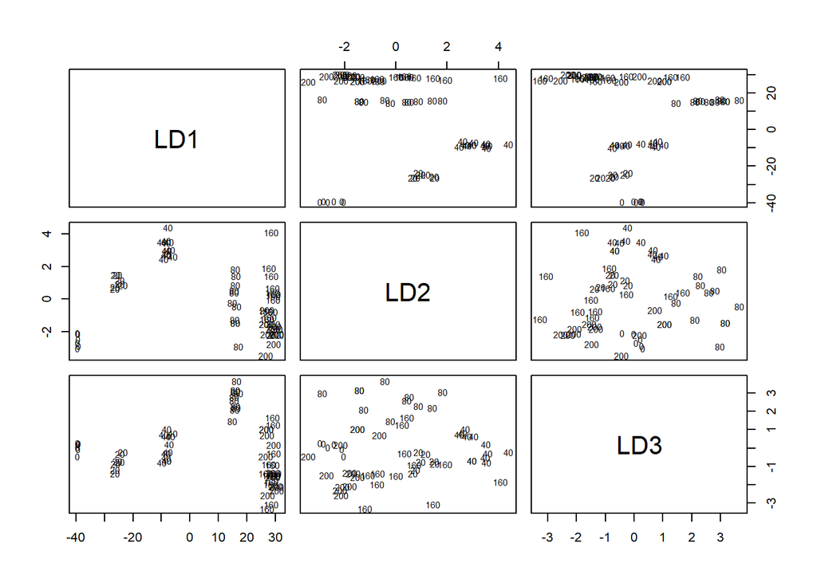

```
## [1] "Confusion Matrix With Original Data"
##
##        0 20 40 80 160 200
##   0    6  0  0  0   0   0
##   20   0  7  0  0   0   0
##   40   0  0 12  0   0   0
##   80   0  0  0 11   0   0
##   160  0  0  0  0  10   1
##   200  0  0  0  0   2  12
## [1] "Total Prediction Accuracy"
## [1] 95.08197
## [1] "0 Prediction Accuracy"
## [1] 100
## [1] "20 Prediction Accuracy"
## [1] 100
```

[output cut: 31 more lines]

```r
LDA_MODEL("nitrate")
```

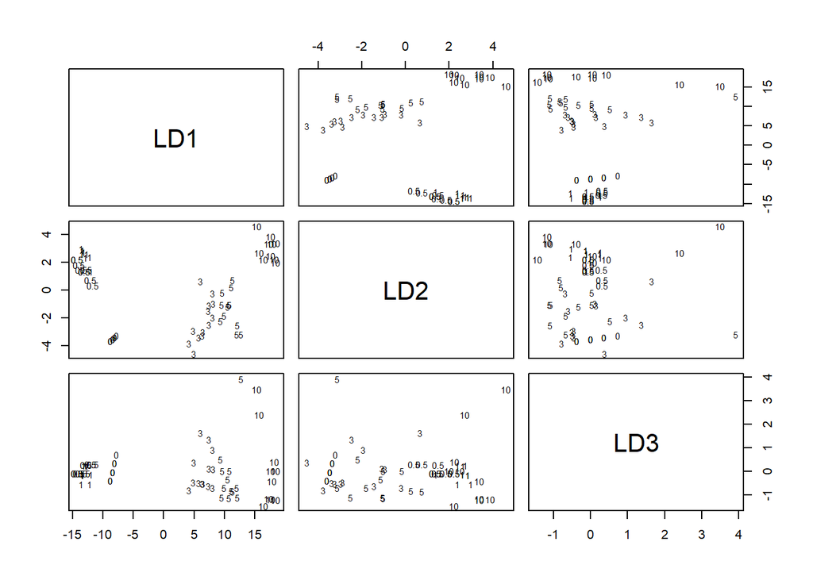

```
## [1] "Confusion Matrix with Original Data"
##
##        0 0.5  1  3  5 10
##   0    8   0  0  0  0  0
##   0.5  0   7  1  0  0  0
##   1    0   2  9  0  0  0
##   3    0   0  0 13  0  0
##   5    0   0  0  0 12  0
##   10   0   0  0  0  0 10
## [1] "Total Prediction Accuracy"
## [1] 95.16129
## [1] "0 Prediction Accuracy"
## [1] 100
## [1] "0.5 Prediction Accuracy"
## [1] 87.5
```

[output cut: 31 more lines]

```r
LDA_MODEL("nitrite")
```

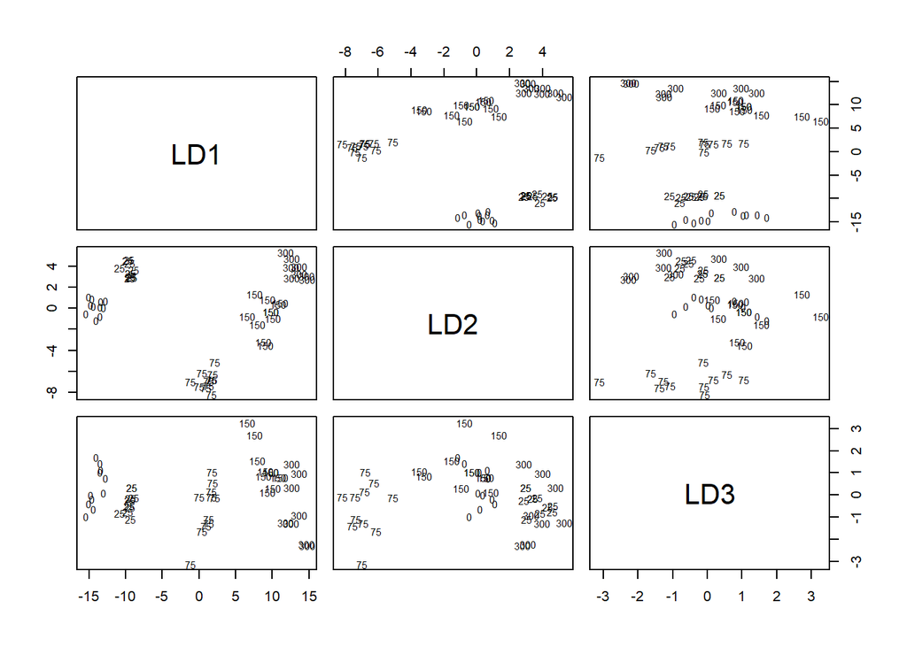

```
## [1] "Confusion Matrix With Original Data"
##
##        0 25 75 150 300
##   0   11  0  0   0   0
##   25   0 11  0   0   0
##   75   0  0 11   0   0
##   150  0  0  0  11   0
##   300  0  0  0   0   8
## [1] "Total Prediction Accuracy"
## [1] 100
## [1] "0 Prediction Accuracy"
## [1] 100
## [1] "25 Prediction Accuracy"
## [1] 100
## [1] "75 Prediction Accuracy"
```

[output cut: 25 more lines]

```r
LDA_MODEL("hardness")
```

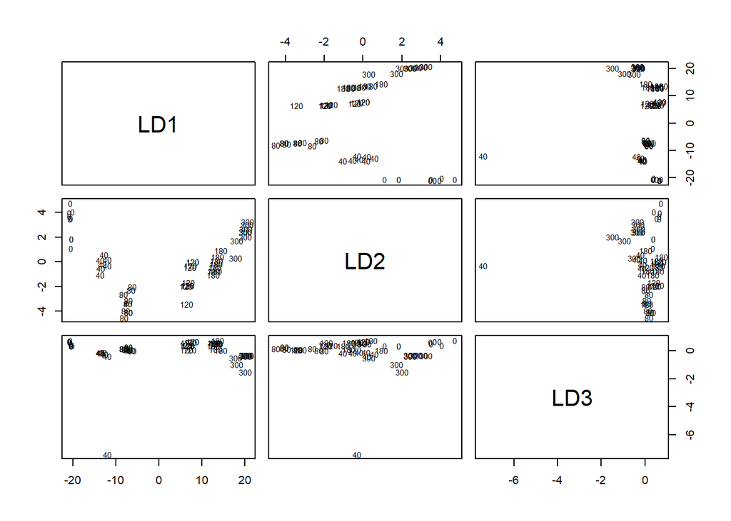

```
## [1] "Confusion Matrix With Original Data"
##
##        0 40 80 120 180 300
##   0    9  0  0   0   0   0
##   40   0  7  0   0   0   0
##   80   0  1 10   0   0   0
##   120  0  0  0   9   0   0
##   180  0  0  0   0   9   0
##   300  0  0  0   0   0  10
## [1] "Total Prediction Accuracy"
## [1] 98.18182
## [1] "0 Prediction Accuracy"
## [1] 100
## [1] "40 Prediction Accuracy"
## [1] 100
```

[output cut: 31 more lines]

```r
LDA_MODEL("alkilinity")
```

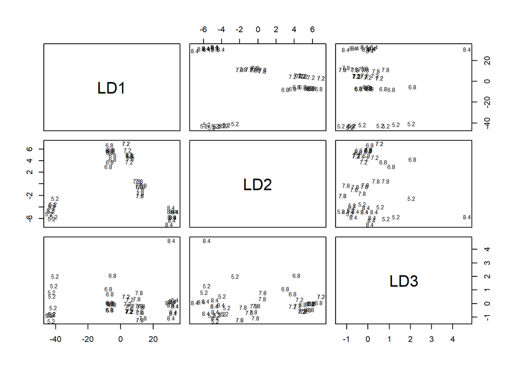

```
## [1] "Confusion Matrix with Original Data"
##
##       5.2 6.8 7.2 7.8 8.4
##   5.2  10   0   0   0   0
##   6.8   0  10   0   0   0
##   7.2   0   0  10   0   0
##   7.8   0   0   0  10   0
##   8.4   0   0   0   0  11
## [1] "Total Prediction Accuracy"
## [1] 100
## [1] "5.2 Prediction Accuracy"
## [1] 100
## [1] "6.8 Prediction Accuracy"
## [1] 100
## [1] "7.2 Prediction Accuracy"
## [1] 100
## [1] "7.8 Prediction Accuracy"
## [1] 100
## [1] "8.4 Prediction Accuracy"
## [1] 100
## [1] "Confusion Matrix with Test Data"
##
##       5.2 6.8 7.2 7.8 8.4
##   5.2  10   0   0   0   0
##   6.8   0  10   0   0   0
##   7.2   0   0  10   0   0
##   7.8   0   0   0  10   0
##   8.4   0   0   0   0  11
## [1] "Total Prediction Accuracy"
## [1] 100
## [1] "5.2 Prediction Accuracy"
## [1] 100
## [1] "6.8 Prediction Accuracy"
## [1] 100
## [1] "7.2 Prediction Accuracy"
## [1] 100
## [1] "7.8 Prediction Accuracy"
## [1] 100
## [1] "8.4 Prediction Accuracy"
## [1] 100
```

```r
LDA_MODEL("pH")
```

# Conclusion

The function LDA_MODEL was successful in creating surpervised learning models for all of the data sheets. This function is resuable and will be able to create a LDA even if the RGB values are in different units. A similar function could also be used for similar color classification projects. As this project moves forward this function will be applied to data read into excel via a color sensor on an ardruino.